# Neighborhood Score: Benchmarking - Report

Jiangtao Xu

9/21/2017

## Execution Environment:

Java Version: 1.8.0_144 OS version: macOS 10.12.6 Processor Name: Intel Core i7 Processor Speed: 2.8GHZ Total Number of Cores: 4 Memory: 16GB

## Design of Evaluated Programs:

This evaluated programs will collect execution-time information for the sequential and concurrent programs. For sequential or concurrent programs with threads from 2 to 16, each program would run 10 times. Collecting 10 times running time and calculate the mean and variance of each variant. Finally analyze the tendency with threads and program stablility.

## About Variance:

There are 2 java programs: Subtask01.java is a sequential program, reading from 100 files and calculating the neighborhood score in steps;Subtask02.java is a parallel/concurrent program, as for Subtask02.java, I) firstly it divides 100 files into K parts(K is the number of Threads from 2 to 16), then counts the frequency of letter in each part and merge results to get the letter scores among to 100 files. II) According to the letters scores, recount each part parallelly to get K clusters’ neighborhood scores. Finally, merge the K clusters’ scores together.

Since wordcount and lettercount cost lots of CPU resource, when running the sequential program, it would take a long time to finish the calculation(around 15 seconds on the testing machine). As for parallel/concurrent program, the calculation have been divided into different CPU cores. Less resource competition, less time to finish the job.

Another interference: sometime, reading from 100 files and writing to CSV takes much more time than word count, the I/O time sometime occupies more than 50% of the total running time. So when considering the interference, I/O would be a big deal.

## Details:

### Sequential Implementation

The output of 10 runs are stored in 1.out. This reads the data into R and converts time from milliseconds to seconds. The frequency histogram of sequential program:

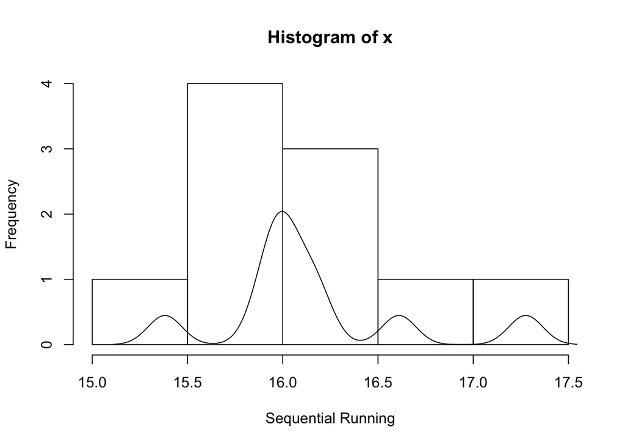

### Concurrent Implementation

Concurrent program with thread from 2 to 16 would run 10 times, we calculate the mean and variance of the running time to determine which program is fast or stable.

```
## 1 16.1486 0.2484498
## 2 10.7301 0.5459572
## 3 10.964 0.7231869
## 4 10.3891 0.5543068
## 5 10.82 0.6208611
## 6 11.174 0.6083096
## 7 10.77 0.3421113
## 8 10.1793 0.6758176
## 9 9.9104 0.8814654
## 10 9.8603 0.5950376
## 11 9.8463 0.5215013
## 12 9.994 0.7025142
## 13 10.2498 0.421092
## 14 11.8229 30.90351
## 15 10.1354 0.3177629
## 16 10.3742 0.31442
```

Mean running time with the increasing number of threads:

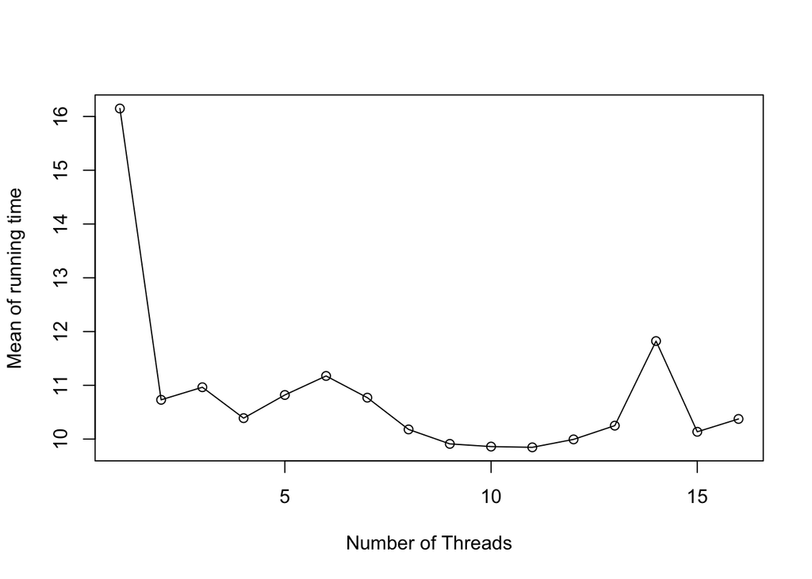

Variance of running time with the increasing number of threads:

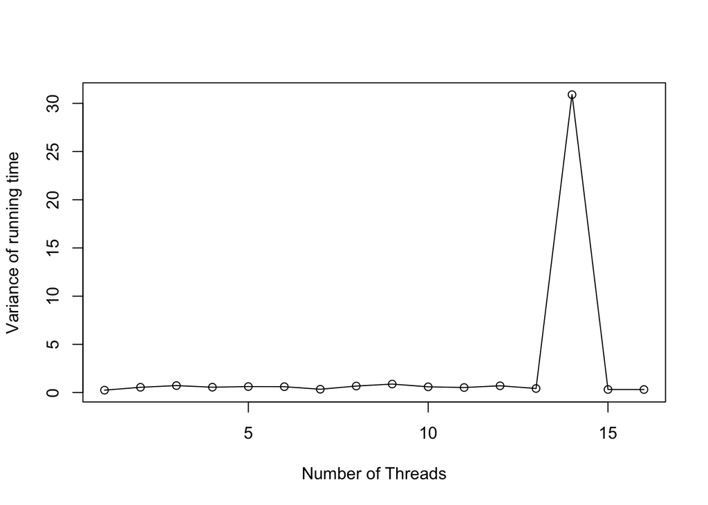

The most fast program and its number of threads:

```
## number of threads: 11 is fast
## We see how the time converges towards mean of the fast program:
```

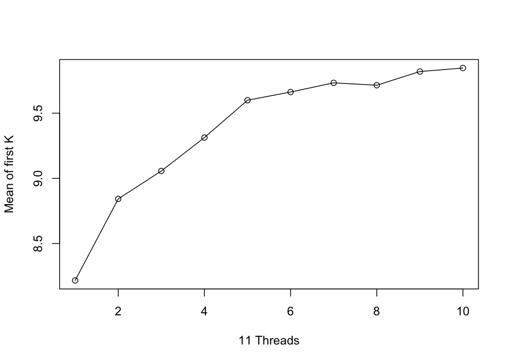

The most stable program and its number of threads:

```
## number of threads: 1 is stable
## We see how the time converges towards mean of the stable program:
```

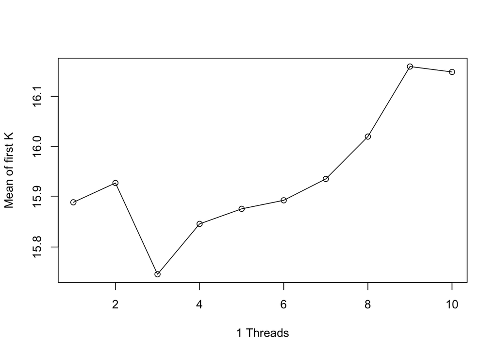